# finaltutorial

# **working towards predictive model one**

*As mentioned in the project goals, I would like to create a predictive model where finishing position is the dependent variable of which we are predicting for. I will groupby circuitID and driverID to determine average lap speed, the fastest lap speed and the fastest lap time given a particular driver at a particular circuit. Utilizing these three metrics, I will then take the historical data and predict how a particular driver with X average lap speed, Y fastest lap speed, and Z fastest lap time will perform at a particular circuit.*

**Steps to build this regression model**

1. *Merge the results dataframe with the races dataframe to obtain information on which circuit was driven at a particular race.*

**please note that anything italicized has not yet been completed**

## *background information*

**Where do Formula One races occur?**

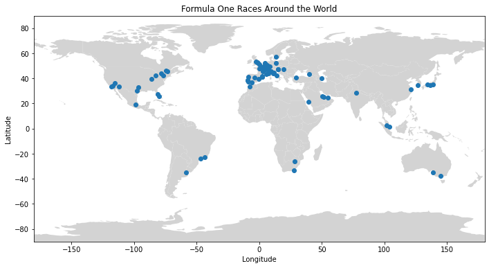

```python
# Creating a map that shows where Formula One races have occurred over the past 70+ years
# Note that some of these circuits are no longer operational/used
# I used information from https://towardsdatascience.com/easiest-way-to-plot-on-a-world-map-with-pandas-and-geopandas-325f6024949f to build my map

# Utilizing GeoPandas to build out a world map
map_of_circuits = gpd.read_file(gpd.datasets.get_path("naturalearth_lowres"))
# Creating axes and plotting world map
fig, ax = plt.subplots(figsize=(12, 6))
map_of_circuits.plot(color="lightgrey", ax=ax)
# Specifying X and Y and plotting them on top of the world map
x = circuits['lng']
y = circuits['lat']
plt.scatter(x, y)
# Limiting each axis and adding a graph title
plt.xlim([-180, 180])
plt.ylim([-90, 90])
plt.title('Formula One Races Around the World')
# Renaming each axis
plt.xlabel("Longitude")
plt.ylabel("Latitude")
# Showing the final product
plt.show()
# As we can see, Formula One is very Euro-centric. The majority of their circuits are within Western European countries.
```

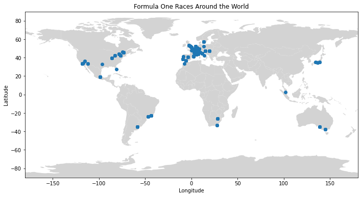

```python
# Where have races occurred historically?
circuits_hist = pd.merge(circuits, races[['circuitId','year']], on='circuitId', how='left')
circuits_hist= circuits_hist.loc[circuits_hist['year']<2000]
# Utilizing GeoPandas to build out a world map
map_of_circuits_hist = gpd.read_file(gpd.datasets.get_path("naturalearth_lowres"))
# Creating axes and plotting world map
fig, ax = plt.subplots(figsize=(12, 6))
map_of_circuits_hist.plot(color="lightgrey", ax=ax)
# Specifying X and Y and plotting them on top of the world map
x = circuits_hist['lng']
y = circuits_hist['lat']
plt.scatter(x, y)
# Limiting each axis and adding a graph title
plt.xlim([-180, 180])
plt.ylim([-90, 90])
plt.title('Formula One Races Around the World')
# Renaming each axis
plt.xlabel("Longitude")
plt.ylabel("Latitude")
# Showing the final product
plt.show()
```

*Prior to 2000, there were at least 10 opperational circuits within the Americas, however the majority of races were heavily centralized in Western Europe*

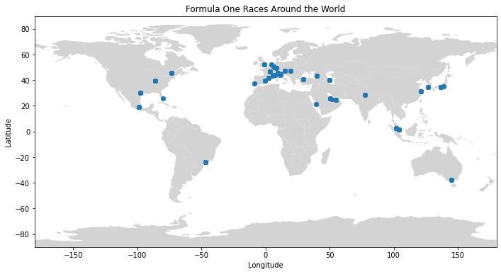

```python
# Where have races occurred in the past 20 years?
circuits_years = pd.merge(circuits, races[['circuitId','year']], on='circuitId', how='left')
circuits_years = circuits_years.loc[circuits_years['year']>=2000]
# Utilizing GeoPandas to build out a world map
map_of_circuits_recent = gpd.read_file(gpd.datasets.get_path("naturalearth_lowres"))
# Creating axes and plotting world map
fig, ax = plt.subplots(figsize=(12, 6))
map_of_circuits_recent.plot(color="lightgrey", ax=ax)
# Specifying X and Y and plotting them on top of the world map
x = circuits_years['lng']
y = circuits_years['lat']
plt.scatter(x, y)
# Limiting each axis and adding a graph title
plt.xlim([-180, 180])
plt.ylim([-90, 90])
plt.title('Formula One Races Around the World')
# Renaming each axis
plt.xlabel("Longitude")
plt.ylabel("Latitude")
# Showing the final product
plt.show()
```

*Since 2000, Formula One races have spread out to Eastern Europe and parts of Asia. However, the frequency of races in the Americas has drastically decreased*

## *limiting the results dataframe*

```python
# Creating a dataframe with the variables I want to use in my first predictive model
# We will be using milliseconds incorporating into the model
results2 = results.drop(columns=['resultId', 'constructorId', 'number', 'positionText','positionOrder', 'time'])
# Renaming the columns for ease of understanding
results2 = results2.rename(columns= {"grid" : "starting_position", "position":"finishing_position", "rank" : "overall_standing", "milliseconds":"time_milliseconds"})
# Filling in lap times with \N with 0 for ease of understanding
results2 = results2.replace('\\N','0')
# Changing the dtypes to be appropriate
results2['time_milliseconds'] = results2['time_milliseconds'].astype(int)
results2['finishing_position'] = results2['finishing_position'].astype(int)
results2['overall_standing'] = results2['overall_standing'].astype(int)
results2['statusId'] = results2['statusId'].astype(str)
results2['fastestLap'] = results2['fastestLap'].astype(int)
results2['fastestLapSpeed'] = results2['fastestLapSpeed'].astype(float)
results2
```

|  | raceId | driverId | starting_position | finishing_position | points | laps | time_milliseconds | fastestLap | overall_standing | fastestLapTime | fastestLapSpeed | statusId |
| --- | --- | --- | --- | --- | --- | --- | --- | --- | --- | --- | --- | --- |
| 0 | 18 | 1 | 1 | 1 | 10.0 | 58 | 5690616 | 39 | 2 | 1:27.452 | 218.300 | 1 |
| 1 | 18 | 2 | 5 | 2 | 8.0 | 58 | 5696094 | 41 | 3 | 1:27.739 | 217.586 | 1 |
| 2 | 18 | 3 | 7 | 3 | 6.0 | 58 | 5698779 | 41 | 5 | 1:28.090 | 216.719 | 1 |
| 3 | 18 | 4 | 11 | 4 | 5.0 | 58 | 5707797 | 58 | 7 | 1:28.603 | 215.464 | 1 |
| 4 | 18 | 5 | 3 | 5 | 4.0 | 58 | 5708630 | 43 | 1 | 1:27.418 | 218.385 | 1 |
| ... | ... | ... | ... | ... | ... | ... | ... | ... | ... | ... | ... | ... |
| 25655 | 1086 | 825 | 13 | 16 | 0.0 | 69 | 0 | 37 | 15 | 1:23.511 | 188.856 | 11 |
| 25656 | 1086 | 848 | 17 | 17 | 0.0 | 69 | 0 | 43 | 12 | 1:23.047 | 189.911 | 11 |
| 25657 | 1086 | 849 | 19 | 18 | 0.0 | 69 | 0 | 60 | 8 | 1:22.478 | 191.221 | 11 |
| 25658 | 1086 | 852 | 16 | 19 | 0.0 | 68 | 0 | 58 | 16 | 1:23.538 | 188.795 | 12 |
| 25659 | 1086 | 822 | 8 | 20 | 0.0 | 65 | 0 | 60 | 19 | 1:24.002 | 187.752 | 131 |

25660 rows × 12 columns

```python
results2.dtypes
# All of the variables within this dataframe will be counted as quantitative excepts for the fastest lap time and the status ID
# I cannot figure out how change the fastest lap time to data time because the seconds contain a decimal
# For now we will leave statusID as an object becuase the numbers refer to specific categories regarding how a driver finished or what may have caused an incomplete race
```

```
raceId                  int64
driverId                int64
starting_position       int64
finishing_position      int64
points                float64
laps                    int64
time_milliseconds       int64
fastestLap              int64
overall_standing        int64
fastestLapTime         object
fastestLapSpeed       float64
statusId               object
dtype: object
```

## *merging the new results dataframe with important indicators from pit stops, qualifying, and lap times*

```python
# creating a dataframe that merges important information from qualifiers, laps, and pitstops
merge1 = pd.merge(laps, qualifying,  how='inner', on=['raceId','driverId'])
reg1 = pd.merge(merge1, results2,  how='inner', on=['raceId','driverId'])
reg1 = reg1.drop(columns=[ 'points', 'laps', 'qualifyId', 'constructorId', 'starting_position_x'])
reg1 = reg1.rename(columns={"starting_position_y":"starting_position"})
reg1 = reg1[['raceId', 'driverId', 'starting_position', 'finishing_position', 'time_milliseconds', 'lap', 'lap_in_milli', 'stop_#', 'stop_in_milli', 'top_ten', 'middle', 'bottom_five']]
reg1
```

|  | raceId | driverId | starting_position | finishing_position | time_milliseconds | lap | lap_in_milli | stop_# | stop_in_milli | top_ten | middle | bottom_five |
| --- | --- | --- | --- | --- | --- | --- | --- | --- | --- | --- | --- | --- |
| 0 | 841 | 20 | 1 | 1 | 5370259 | 1 | 98109 | NaN | NaN | 1 | 0 | 0 |
| 1 | 841 | 20 | 1 | 1 | 5370259 | 2 | 93006 | NaN | NaN | 1 | 0 | 0 |
| 2 | 841 | 20 | 1 | 1 | 5370259 | 3 | 92713 | NaN | NaN | 1 | 0 | 0 |
| 3 | 841 | 20 | 1 | 1 | 5370259 | 4 | 92803 | NaN | NaN | 1 | 0 | 0 |
| 4 | 841 | 20 | 1 | 1 | 5370259 | 5 | 92342 | NaN | NaN | 1 | 0 | 0 |
| ... | ... | ... | ... | ... | ... | ... | ... | ... | ... | ... | ... | ... |
| 443843 | 1086 | 842 | 0 | 12 | 0 | 65 | 85989 | NaN | NaN | 0 | 0 | 1 |
| 443844 | 1086 | 842 | 0 | 12 | 0 | 66 | 85187 | NaN | NaN | 0 | 0 | 1 |
| 443845 | 1086 | 842 | 0 | 12 | 0 | 67 | 107355 | NaN | NaN | 0 | 0 | 1 |
| 443846 | 1086 | 842 | 0 | 12 | 0 | 68 | 97587 | NaN | NaN | 0 | 0 | 1 |
| 443847 | 1086 | 842 | 0 | 12 | 0 | 69 | 89072 | NaN | NaN | 0 | 0 | 1 |

443848 rows × 12 columns

```python
reg1.corr()
```

|  | raceId | driverId | starting_position | finishing_position | time_milliseconds | lap | lap_in_milli | stop_# | stop_in_milli | top_ten | middle | bottom_five |
| --- | --- | --- | --- | --- | --- | --- | --- | --- | --- | --- | --- | --- |
| raceId | 1.000000 | 0.645585 | -0.000126 | 0.142774 | 0.069656 | 0.009465 | 0.034660 | -0.085605 | 0.181956 | 0.260184 | 0.066118 | -0.320646 |
| driverId | 0.645585 | 1.000000 | 0.159111 | 0.234367 | -0.068945 | 0.003876 | 0.015814 | -0.036885 | 0.052074 | 0.064440 | 0.095186 | -0.145473 |
| starting_position | -0.000126 | 0.159111 | 1.000000 | 0.559073 | -0.474941 | -0.032303 | 0.018324 | 0.017409 | -0.015841 | -0.625964 | 0.175010 | 0.491403 |
| finishing_position | 0.142774 | 0.234367 | 0.559073 | 1.000000 | -0.371118 | 0.067250 | 0.005776 | 0.067014 | -0.035471 | -0.324631 | 0.150485 | 0.204787 |
| time_milliseconds | 0.069656 | -0.068945 | -0.474941 | -0.371118 | 1.000000 | 0.065056 | 0.042762 | 0.061551 | 0.155967 | 0.381555 | -0.069000 | -0.331115 |
| lap | 0.009465 | 0.003876 | -0.032303 | 0.067250 | 0.065056 | 1.000000 | -0.070720 | 0.597223 | -0.100313 | 0.027697 | -0.002464 | -0.026168 |
| lap_in_milli | 0.034660 | 0.015814 | 0.018324 | 0.005776 | 0.042762 | -0.070720 | 1.000000 | 0.118099 | 0.294011 | -0.000382 | 0.011382 | -0.009150 |
| stop_# | -0.085605 | -0.036885 | 0.017409 | 0.067014 | 0.061551 | 0.597223 | 0.118099 | 1.000000 | 0.042437 | -0.029625 | 0.013136 | 0.021114 |
| stop_in_milli | 0.181956 | 0.052074 | -0.015841 | -0.035471 | 0.155967 | -0.100313 | 0.294011 | 0.042437 | 1.000000 | 0.003007 | 0.000847 | -0.004318 |
| top_ten | 0.260184 | 0.064440 | -0.625964 | -0.324631 | 0.381555 | 0.027697 | -0.000382 | -0.029625 | 0.003007 | 1.000000 | -0.434030 | -0.655581 |
| middle | 0.066118 | 0.095186 | 0.175010 | 0.150485 | -0.069000 | -0.002464 | 0.011382 | 0.013136 | 0.000847 | -0.434030 | 1.000000 | -0.395749 |
| bottom_five | -0.320646 | -0.145473 | 0.491403 | 0.204787 | -0.331115 | -0.026168 | -0.009150 | 0.021114 | -0.004318 | -0.655581 | -0.395749 | 1.000000 |

*finishing position is most correlated with starting_position, time_milliseconds, and the three dummy indicators for where in the grid the driver started.*

# **working through the second predictive model**

*As mentioned in the project goals, I want to determine the role that the constructor, rather than the driver, plays in how races turn out. Within a Formula 1 season, there are two important competitions happening at any given time. These two competitions are the Driver's world championship and the constructors world champtionship. Where my previous model predicted how a driver may do at a given race, I want to build my second model to predict how a constructor will do in a given season based on the lineup of races. I will utilize similar data as before, however, know I will also include information based on the constructors and I will group driverIDs based on who they are racing for within a given season*

# **exceess information still to be worked through**

**The Constructor Datasets**

- I want to use this dataset to help determine if the driver or the engine is more integral to winning the race
- Performing somewhat of a difference-in-differences analysis, I can compare how different drivers who switch teams perform overtime. Does the constructor vastly improve their performance or does other factors?

```python
constructors_final = constructor_standings.merge(constructors, how="inner", on='constructorId').drop(['nationality','url','positionText','wins'],axis=1)
constructors_final
```

|  | constructorStandingsId | raceId | constructorId | points | position | constructorRef | name |
| --- | --- | --- | --- | --- | --- | --- | --- |
| 0 | 1 | 18 | 1 | 14.0 | 1 | mclaren | McLaren |
| 1 | 7 | 19 | 1 | 24.0 | 1 | mclaren | McLaren |
| 2 | 18 | 20 | 1 | 28.0 | 3 | mclaren | McLaren |
| 3 | 29 | 21 | 1 | 34.0 | 3 | mclaren | McLaren |
| 4 | 40 | 22 | 1 | 42.0 | 3 | mclaren | McLaren |
| ... | ... | ... | ... | ... | ... | ... | ... |
| 12836 | 28227 | 1082 | 214 | 57.0 | 5 | alpine | Alpine F1 Team |
| 12837 | 28237 | 1083 | 214 | 67.0 | 5 | alpine | Alpine F1 Team |
| 12838 | 28247 | 1084 | 214 | 81.0 | 5 | alpine | Alpine F1 Team |
| 12839 | 28257 | 1085 | 214 | 93.0 | 4 | alpine | Alpine F1 Team |
| 12840 | 28267 | 1086 | 214 | 99.0 | 4 | alpine | Alpine F1 Team |

12841 rows × 7 columns

```python
driver_standings.head()
```

|  | driverStandingsId | raceId | driverId | points | position | positionText | wins |
| --- | --- | --- | --- | --- | --- | --- | --- |
| 0 | 1 | 18 | 1 | 10.0 | 1 | 1 | 1 |
| 1 | 2 | 18 | 2 | 8.0 | 2 | 2 | 0 |
| 2 | 3 | 18 | 3 | 6.0 | 3 | 3 | 0 |
| 3 | 4 | 18 | 4 | 5.0 | 4 | 4 | 0 |
| 4 | 5 | 18 | 5 | 4.0 | 5 | 5 | 0 |

```python
drivers.head()
```

|  | driverId | driverRef | number | code | forename | surname | dob | nationality | url |
| --- | --- | --- | --- | --- | --- | --- | --- | --- | --- |
| 0 | 1 | hamilton | 44 | HAM | Lewis | Hamilton | 1985-01-07 | British | http://en.wikipedia.org/wiki/Lewis_Hamilton |
| 1 | 2 | heidfeld | \N | HEI | Nick | Heidfeld | 1977-05-10 | German | http://en.wikipedia.org/wiki/Nick_Heidfeld |
| 2 | 3 | rosberg | 6 | ROS | Nico | Rosberg | 1985-06-27 | German | http://en.wikipedia.org/wiki/Nico_Rosberg |
| 3 | 4 | alonso | 14 | ALO | Fernando | Alonso | 1981-07-29 | Spanish | http://en.wikipedia.org/wiki/Fernando_Alonso |
| 4 | 5 | kovalainen | \N | KOV | Heikki | Kovalainen | 1981-10-19 | Finnish | http://en.wikipedia.org/wiki/Heikki_Kovalainen |

```python
# Cleaning uneccesary rows
races = races.drop(['fp1_date', 'fp1_time', 'fp2_date', 'fp2_time', 'fp3_date', 'fp3_time', 'quali_date', 'quali_time', 'sprint_date', 'sprint_time', 'url'], axis=1)
races.head()
```

|  | raceId | year | round | circuitId | name | date | time |
| --- | --- | --- | --- | --- | --- | --- | --- |
| 0 | 1 | 2009 | 1 | 1 | Australian Grand Prix | 2009-03-29 | 06:00:00 |
| 1 | 2 | 2009 | 2 | 2 | Malaysian Grand Prix | 2009-04-05 | 09:00:00 |
| 2 | 3 | 2009 | 3 | 17 | Chinese Grand Prix | 2009-04-19 | 07:00:00 |
| 3 | 4 | 2009 | 4 | 3 | Bahrain Grand Prix | 2009-04-26 | 12:00:00 |
| 4 | 5 | 2009 | 5 | 4 | Spanish Grand Prix | 2009-05-10 | 12:00:00 |

```python
# Adding text information on the status of each driver in a race.
results = results.merge(status, how='inner', on='statusId')
# Adding text information on who each driver was
results = results.merge(drivers, how='inner', on='driverId').drop(['url','dob','nationality','number_x','positionText','positionOrder','number_y', 'time'], axis=1)
results
```

|  | resultId | raceId | driverId | constructorId | grid | position | points | laps | milliseconds | fastestLap | rank | fastestLapTime | fastestLapSpeed | statusId | status | driverRef | code | forename | surname |
| --- | --- | --- | --- | --- | --- | --- | --- | --- | --- | --- | --- | --- | --- | --- | --- | --- | --- | --- | --- |
| 0 | 1 | 18 | 1 | 1 | 1 | 1 | 10.0 | 58 | 5690616 | 39 | 2 | 1:27.452 | 218.300 | 1 | Finished | hamilton | HAM | Lewis | Hamilton |
| 1 | 27 | 19 | 1 | 1 | 9 | 5 | 4.0 | 56 | 5525103 | 53 | 3 | 1:35.462 | 209.033 | 1 | Finished | hamilton | HAM | Lewis | Hamilton |
| 2 | 69 | 21 | 1 | 1 | 5 | 3 | 6.0 | 66 | 5903238 | 20 | 3 | 1:22.017 | 204.323 | 1 | Finished | hamilton | HAM | Lewis | Hamilton |
| 3 | 90 | 22 | 1 | 1 | 3 | 2 | 8.0 | 58 | 5213230 | 31 | 2 | 1:26.529 | 222.085 | 1 | Finished | hamilton | HAM | Lewis | Hamilton |
| 4 | 109 | 23 | 1 | 1 | 3 | 1 | 10.0 | 76 | 7242742 | 71 | 6 | 1:18.510 | 153.152 | 1 | Finished | hamilton | HAM | Lewis | Hamilton |
| ... | ... | ... | ... | ... | ... | ... | ... | ... | ... | ... | ... | ... | ... | ... | ... | ... | ... | ... | ... |
| 25655 | 17583 | 726 | 448 | 98 | 21 | 7 | 0.0 | 88 | \N | \N | \N | \N | \N | 115 | +22 Laps | broeker | \N | Peter | Broeker |
| 25656 | 19598 | 815 | 719 | 133 | 18 | 9 | 0.0 | 49 | \N | \N | \N | \N | \N | 116 | +16 Laps | scherrer | \N | Albert | Scherrer |
| 25657 | 20204 | 809 | 804 | 113 | 14 | 17 | 0.0 | 176 | \N | \N | \N | \N | \N | 117 | +24 Laps | mantz | \N | Johnny | Mantz |
| 25658 | 20045 | 833 | 790 | 151 | 12 | \N | 0.0 | 2 | \N | \N | \N | \N | \N | 126 | Supercharger | leslie_johnson | \N | Leslie | Johnson |
| 25659 | 22394 | 911 | 827 | 207 | 21 | \N | 0.0 | 1 | \N | \N | 0 | \N | \N | 131 | Power Unit | lotterer | LOT | André | Lotterer |

25660 rows × 19 columns

```python
sprint_results = sprint_results.drop(['time', 'positionOrder','positionText'],axis=1)
sprint_results
```

|  | resultId | raceId | driverId | constructorId | number | grid | position | points | laps | milliseconds | fastestLap | fastestLapTime | statusId |
| --- | --- | --- | --- | --- | --- | --- | --- | --- | --- | --- | --- | --- | --- |
| 0 | 1 | 1061 | 830 | 9 | 33 | 2 | 1 | 3 | 17 | 1538426 | 14 | 1:30.013 | 1 |
| 1 | 2 | 1061 | 1 | 131 | 44 | 1 | 2 | 2 | 17 | 1539856 | 17 | 1:29.937 | 1 |
| 2 | 3 | 1061 | 822 | 131 | 77 | 3 | 3 | 1 | 17 | 1545928 | 17 | 1:29.958 | 1 |
| 3 | 4 | 1061 | 844 | 6 | 16 | 4 | 4 | 0 | 17 | 1549704 | 16 | 1:30.163 | 1 |
| 4 | 5 | 1061 | 846 | 1 | 4 | 6 | 5 | 0 | 17 | 1562537 | 16 | 1:30.566 | 1 |
| ... | ... | ... | ... | ... | ... | ... | ... | ... | ... | ... | ... | ... | ... |
| 95 | 96 | 1084 | 848 | 3 | 23 | 11 | 16 | 0 | 23 | 1642471 | 5 | 1:10.367 | 1 |
| 96 | 97 | 1084 | 852 | 213 | 22 | 14 | 17 | 0 | 23 | 1644615 | 4 | 1:10.267 | 1 |
| 97 | 98 | 1084 | 849 | 3 | 6 | 19 | 18 | 0 | 23 | 1658753 | 4 | 1:10.284 | 1 |
| 98 | 99 | 1084 | 20 | 117 | 5 | 20 | 19 | 0 | 21 | \N | 4 | 1:10.317 | 130 |
| 99 | 100 | 1084 | 4 | 214 | 14 | 8 | \N | 0 | 0 | \N | \N | \N | 10 |

100 rows × 13 columns

**Trying to find some Summary Statistics**

```python
# Do those who qualify well, and ultimatly race well, have shorter or faster pitstops?
pit_qual= pit_stops.merge(qualifying, how = "outer", on= ["raceId","driverId"])
pit_qual
```

[output not shown]

14179 rows × 14 columns

```python
pit_qual['position'].corr(pit_qual['milliseconds'])
# There is a slight negative correlation.
# As position increases (which means they drove worse), the time spend in pitstops decreased.
# Those who raced well, on average, have slightly longer pitstops.
```

```
-0.015119818104610494
```

# **Regression Discontinuity**

*observing the effect a team has on drivers*

## **Scaping information from the internet, specific to the ten current racing teams within the last decade**

*For any given Formula One season, there are ten constructors/ teams. The current lineup includes Red Bull Racing, Mercedes, Ferrari, Mclaren, AlphaTauri,Alpine F1 Team, Alfa Romeo, Haas F1 team, Aston Martin & Williams. I have limited my regression discontinuity to these teams because Formula One is both highly transient (in the past 72 years, there have been over 171 constructors) and it is constantly developing (it would be unwise to build a model using information from Ferrari cars 50 years ago to predict how Ferrari will do next year). In addition to limiting the constructors, I have also limited teams that have a large historical footprint in Formula One to only include data from 2010 onwards*

```python
## Red Bull Racing: Drivers by Year
url = 'https://en.wikipedia.org/wiki/Red_Bull_Racing'
headers = {'User-Agent': 'Mozilla/5.0 (Macintosh; Intel Mac OS X 10_10_1) AppleWebKit/537.36 (KHTML, like Gecko) Chrome/39.0.2171.95 Safari/537.36'}
r = requests.get(url, headers=headers)
# importing the ability to use beautiful soup
from bs4 import BeautifulSoup
soup = BeautifulSoup( r.content )

red_bull_drivers = []
for t in soup.findAll("table"):
  df_t = pd.read_html(str(t))
  red_bull_drivers.append(df_t[0])

red_bull_drivers[3] = red_bull_drivers[3].drop(columns = ['Car', 'Engine', 'Tyres', 'No.', 'Points', 'Position', 'Name'])
red_bull_drivers[3] = red_bull_drivers[3].join(red_bull_drivers[3]['Drivers'].str.split( expand =True).rename(
    columns = {0: 'First1', 1: 'Last1', 2:'First2', 3:'Last2', 4:'First3', 5:'Last3'}
))
red_bull_drivers[3]['Driver1'] = red_bull_drivers[3]['First1']  + ' ' + red_bull_drivers[3]['Last1']
red_bull_drivers[3]['Driver2'] = red_bull_drivers[3]['First2']  + ' ' + red_bull_drivers[3]['Last2']
red_bull_drivers[3]['Driver3'] = red_bull_drivers[3]['First3']  + ' ' + red_bull_drivers[3]['Last3']

red_bull_drivers[3] = red_bull_drivers[3].drop(columns = ['Drivers', 'First1', 'Last1', 'First2', 'Last2', 'First3', 'Last3'])
red_bull_drivers[3].drop([18], axis=0, inplace=True)
red_bull_drivers[3] = pd.melt(red_bull_drivers[3], id_vars=['Year'])
red_bull_drivers[3] = red_bull_drivers[3].dropna()
red_bull_drivers[3]['Constructor'] = 'Red Bull'
red_bull_drivers[3] = red_bull_drivers[3].rename(columns={"value": "Driver"})
red_bull_drivers[3] = red_bull_drivers[3].drop(columns = ['variable'])


red_bull_drivers[3]['constructorId'] = '9'


red_bull_drivers[3]
```

|  | Year | Driver | Constructor | constructorId |
| --- | --- | --- | --- | --- |
| 0 | 2005 | David Coulthard | Red Bull | 9 |
| 1 | 2006 | David Coulthard | Red Bull | 9 |
| 2 | 2007 | David Coulthard | Red Bull | 9 |
| 3 | 2008 | David Coulthard | Red Bull | 9 |
| 4 | 2009 | Mark Webber | Red Bull | 9 |
| 5 | 2010 | Sebastian Vettel | Red Bull | 9 |
| 6 | 2011 | Sebastian Vettel | Red Bull | 9 |
| 7 | 2012 | Sebastian Vettel | Red Bull | 9 |
| 8 | 2013 | Sebastian Vettel | Red Bull | 9 |
| 9 | 2014 | Sebastian Vettel | Red Bull | 9 |
| 10 | 2015 | Daniel Ricciardo | Red Bull | 9 |
| 11 | 2016 | Daniel Ricciardo | Red Bull | 9 |
| 12 | 2017 | Daniel Ricciardo | Red Bull | 9 |
| 13 | 2018 | Daniel Ricciardo | Red Bull | 9 |
| 14 | 2019 | Pierre Gasly | Red Bull | 9 |
| 15 | 2020 | Alex Albon | Red Bull | 9 |
| 16 | 2021 | Sergio Pérez | Red Bull | 9 |
| 17 | 2022 | Max Verstappen | Red Bull | 9 |
| 18 | 2005 | Christian Klien | Red Bull | 9 |
| 19 | 2006 | Christian Klien | Red Bull | 9 |
| 20 | 2007 | Mark Webber | Red Bull | 9 |
| 21 | 2008 | Mark Webber | Red Bull | 9 |
| 22 | 2009 | Sebastian Vettel | Red Bull | 9 |
| 23 | 2010 | Mark Webber | Red Bull | 9 |
| 24 | 2011 | Mark Webber | Red Bull | 9 |
| 25 | 2012 | Mark Webber | Red Bull | 9 |
| 26 | 2013 | Mark Webber | Red Bull | 9 |
| 27 | 2014 | Daniel Ricciardo | Red Bull | 9 |
| 28 | 2015 | Daniil Kvyat | Red Bull | 9 |
| 29 | 2016 | Daniil Kvyat | Red Bull | 9 |
| 30 | 2017 | Max Verstappen | Red Bull | 9 |
| 31 | 2018 | Max Verstappen | Red Bull | 9 |
| 32 | 2019 | Alex Albon | Red Bull | 9 |
| 33 | 2020 | Max Verstappen | Red Bull | 9 |
| 34 | 2021 | Max Verstappen | Red Bull | 9 |
| 35 | 2022 | Sergio Pérez | Red Bull | 9 |
| 36 | 2005 | Vitantonio Liuzzi | Red Bull | 9 |
| 37 | 2006 | Robert Doornbos | Red Bull | 9 |
| 47 | 2016 | Max Verstappen | Red Bull | 9 |
| 50 | 2019 | Max Verstappen | Red Bull | 9 |

```python
## Merecedes: Drivers by Year
url = 'https://en.wikipedia.org/wiki/Mercedes-Benz_in_Formula_One'
headers = {'User-Agent': 'Mozilla/5.0 (Macintosh; Intel Mac OS X 10_10_1) AppleWebKit/537.36 (KHTML, like Gecko) Chrome/39.0.2171.95 Safari/537.36'}
r = requests.get(url, headers=headers)
# importing the ability to use beautiful soup
from bs4 import BeautifulSoup
soup = BeautifulSoup( r.content )

mercedes_drivers = []
for t in soup.findAll("table"):
  df_t = pd.read_html(str(t))
  mercedes_drivers.append(df_t[0])

mercedes_drivers[5].drop([2], axis =0, inplace =True)
mercedes_drivers[5] = mercedes_drivers[5][['Year', 'Drivers']]

# Please note that Mercredes raced drivers in 1954 and 1955 before taking a hiatus uintil 2010.
# For the purposes of my analysis on the current Mercedes team, I did not include 1954 - 1955 as the rules were different and there were many more drivers
mercedes_drivers[5].drop([0], axis =0, inplace =True)
mercedes_drivers[5].drop([1], axis =0, inplace =True)
mercedes_drivers[5].drop([16], axis =0, inplace =True)

mercedes_drivers[5] = mercedes_drivers[5].join(mercedes_drivers[5]['Drivers'].str.split( expand =True).rename(
    columns = {0: 'First1', 1: 'Last1', 2:'First2', 3:'Last2', 4:'First3', 5:'Last3'}))

mercedes_drivers[5]['Driver1'] = mercedes_drivers[5]['First1']  + ' ' + mercedes_drivers[5]['Last1']
mercedes_drivers[5]['Driver2'] = mercedes_drivers[5]['First2']  + ' ' + mercedes_drivers[5]['Last2']
mercedes_drivers[5]['Driver3'] = mercedes_drivers[5]['First3']  + ' ' + mercedes_drivers[5]['Last3']

mercedes_drivers[5] = mercedes_drivers[5][['Year', 'Driver1', 'Driver2', 'Driver3']]
mercedes_drivers[5] = pd.melt(mercedes_drivers[5], id_vars=['Year'])
mercedes_drivers[5] = mercedes_drivers[5].dropna()

mercedes_drivers[5]['Constructor'] = 'Mercedes'
mercedes_drivers[5] = mercedes_drivers[5].rename(columns={"value": "Driver"})
mercedes_drivers[5] = mercedes_drivers[5].drop(columns= ['variable'])
mercedes_drivers[5]['constructorId'] = '131'


mercedes_drivers[5]
```

|  | Year | Driver | Constructor | constructorId |
| --- | --- | --- | --- | --- |
| 0 | 2010 | Michael Schumacher | Mercedes | 131 |
| 1 | 2011 | Michael Schumacher | Mercedes | 131 |
| 2 | 2012 | Michael Schumacher | Mercedes | 131 |
| 3 | 2013 | Nico Rosberg | Mercedes | 131 |
| 4 | 2014 | Nico Rosberg | Mercedes | 131 |
| 5 | 2015 | Nico Rosberg | Mercedes | 131 |
| 6 | 2016 | Nico Rosberg | Mercedes | 131 |
| 7 | 2017 | Lewis Hamilton | Mercedes | 131 |
| 8 | 2018 | Lewis Hamilton | Mercedes | 131 |
| 9 | 2019 | Lewis Hamilton | Mercedes | 131 |
| 10 | 2020 | Lewis Hamilton | Mercedes | 131 |
| 11 | 2021 | Lewis Hamilton | Mercedes | 131 |
| 12 | 2022 | Lewis Hamilton | Mercedes | 131 |
| 13 | 2010 | Nico Rosberg | Mercedes | 131 |
| 14 | 2011 | Nico Rosberg | Mercedes | 131 |
| 15 | 2012 | Nico Rosberg | Mercedes | 131 |
| 16 | 2013 | Lewis Hamilton | Mercedes | 131 |
| 17 | 2014 | Lewis Hamilton | Mercedes | 131 |
| 18 | 2015 | Lewis Hamilton | Mercedes | 131 |
| 19 | 2016 | Lewis Hamilton | Mercedes | 131 |
| 20 | 2017 | Valtteri Bottas | Mercedes | 131 |
| 21 | 2018 | Valtteri Bottas | Mercedes | 131 |
| 22 | 2019 | Valtteri Bottas | Mercedes | 131 |
| 23 | 2020 | George Russell | Mercedes | 131 |
| 24 | 2021 | Valtteri Bottas | Mercedes | 131 |
| 25 | 2022 | George Russell | Mercedes | 131 |
| 36 | 2020 | Valtteri Bottas | Mercedes | 131 |

```python
#Ferrari
url = 'https://en.wikipedia.org/wiki/Ferrari_Grand_Prix_results'
headers = {'User-Agent': 'Mozilla/5.0 (Macintosh; Intel Mac OS X 10_10_1) AppleWebKit/537.36 (KHTML, like Gecko) Chrome/39.0.2171.95 Safari/537.36'}
r = requests.get(url, headers=headers)
# importing the ability to use beautiful soup
from bs4 import BeautifulSoup
soup = BeautifulSoup( r.content )

ferrari_drivers = []
for t in soup.findAll("table"):
  df_t = pd.read_html(str(t))
  ferrari_drivers.append(df_t[0])

ferrari_drivers= pd.concat([ferrari_drivers[6], ferrari_drivers[7]], ignore_index=True)

ferrari_drivers = ferrari_drivers[['Year', 'Driver']]
ferrari_drivers = ferrari_drivers.dropna()
ferrari_drivers.drop([30], axis =0, inplace =True)
ferrari_drivers.drop([40], axis =0, inplace =True)


# Adding constructor name
ferrari_drivers['Constructor'] = 'Ferrari'
ferrari_drivers['constructorId'] = '6'


ferrari_drivers
```

|  | Year | Driver | Constructor | constructorId |
| --- | --- | --- | --- | --- |
| 1 | 2010 | Fernando Alonso | Ferrari | 6 |
| 2 | 2010 | Felipe Massa | Ferrari | 6 |
| 4 | 2011 | Fernando Alonso | Ferrari | 6 |
| 5 | 2011 | Felipe Massa | Ferrari | 6 |
| 7 | 2012 | Fernando Alonso | Ferrari | 6 |
| 8 | 2012 | Felipe Massa | Ferrari | 6 |
| 10 | 2013 | Fernando Alonso | Ferrari | 6 |
| 11 | 2013 | Felipe Massa | Ferrari | 6 |
| 13 | 2014 | Fernando Alonso | Ferrari | 6 |
| 14 | 2014 | Kimi Räikkönen | Ferrari | 6 |
| 16 | 2015 | Kimi Räikkönen | Ferrari | 6 |
| 17 | 2015 | Sebastian Vettel | Ferrari | 6 |
| 19 | 2016 | Kimi Räikkönen | Ferrari | 6 |
| 20 | 2016 | Sebastian Vettel | Ferrari | 6 |
| 22 | 2017 | Kimi Räikkönen | Ferrari | 6 |
| 23 | 2017 | Sebastian Vettel | Ferrari | 6 |
| 25 | 2018 | Kimi Räikkönen | Ferrari | 6 |
| 26 | 2018 | Sebastian Vettel | Ferrari | 6 |
| 28 | 2019 | Charles Leclerc | Ferrari | 6 |
| 29 | 2019 | Sebastian Vettel | Ferrari | 6 |
| 32 | 2020 | Charles Leclerc | Ferrari | 6 |
| 33 | 2020 | Sebastian Vettel | Ferrari | 6 |
| 35 | 2021 | Charles Leclerc | Ferrari | 6 |
| 36 | 2021 | Carlos Sainz Jr. | Ferrari | 6 |
| 38 | 2022 | Charles Leclerc | Ferrari | 6 |
| 39 | 2022 | Carlos Sainz Jr. | Ferrari | 6 |

```python
# Mclaren
url = 'https://en.wikipedia.org/wiki/McLaren_Grand_Prix_results'
headers = {'User-Agent': 'Mozilla/5.0 (Macintosh; Intel Mac OS X 10_10_1) AppleWebKit/537.36 (KHTML, like Gecko) Chrome/39.0.2171.95 Safari/537.36'}
r = requests.get(url, headers=headers)
# importing the ability to use beautiful soup
from bs4 import BeautifulSoup
soup = BeautifulSoup( r.content )

mclaren_drivers = []
for t in soup.findAll("table"):
  df_t = pd.read_html(str(t))
  mclaren_drivers.append(df_t[0])

mclaren_drivers = pd.concat([mclaren_drivers[5], mclaren_drivers[6]], ignore_index=True)

mclaren_drivers = mclaren_drivers[['Year', 'Drivers']]
mclaren_drivers = mclaren_drivers.dropna()
mclaren_drivers.drop([33], axis =0, inplace =True)
mclaren_drivers.drop([43], axis =0, inplace =True)


# Adding constructor name
mclaren_drivers['Constructor'] = 'McLaren'
mclaren_drivers = mclaren_drivers.rename(columns={"Drivers": "Driver"})
mclaren_drivers['constructorId'] = '1'


mclaren_drivers
```

|  | Year | Driver | Constructor | constructorId |
| --- | --- | --- | --- | --- |
| 1 | 2010 | Jenson Button | McLaren | 1 |
| 2 | 2010 | Lewis Hamilton | McLaren | 1 |
| 4 | 2011 | Jenson Button | McLaren | 1 |
| 5 | 2011 | Lewis Hamilton | McLaren | 1 |
| 7 | 2012 | Jenson Button | McLaren | 1 |
| 8 | 2012 | Lewis Hamilton | McLaren | 1 |
| 10 | 2013 | Jenson Button | McLaren | 1 |
| 11 | 2013 | Sergio Pérez | McLaren | 1 |
| 13 | 2014 | Jenson Button | McLaren | 1 |
| 14 | 2014 | Kevin Magnussen | McLaren | 1 |
| 16 | 2015 | Jenson Button | McLaren | 1 |
| 17 | 2015 | Kevin Magnussen | McLaren | 1 |
| 18 | 2015 | Fernando Alonso | McLaren | 1 |
| 20 | 2016 | Fernando Alonso | McLaren | 1 |
| 21 | 2016 | Stoffel Vandoorne | McLaren | 1 |
| 22 | 2016 | Jenson Button | McLaren | 1 |
| 24 | 2017 | Fernando Alonso | McLaren | 1 |
| 25 | 2017 | Jenson Button | McLaren | 1 |
| 26 | 2017 | Stoffel Vandoorne | McLaren | 1 |
| 28 | 2018 | Fernando Alonso | McLaren | 1 |
| 29 | 2018 | Stoffel Vandoorne | McLaren | 1 |
| 31 | 2019 | Lando Norris | McLaren | 1 |
| 32 | 2019 | Carlos Sainz Jr. | McLaren | 1 |
| 35 | 2020 | Lando Norris | McLaren | 1 |
| 36 | 2020 | Carlos Sainz Jr. | McLaren | 1 |
| 38 | 2021 | Lando Norris | McLaren | 1 |
| 39 | 2021 | Daniel Ricciardo | McLaren | 1 |
| 41 | 2022 | Lando Norris | McLaren | 1 |
| 42 | 2022 | Daniel Ricciardo | McLaren | 1 |

```python
# BWT Alpine
url = 'https://en.wikipedia.org/wiki/Alpine_F1_Team'
headers = {'User-Agent': 'Mozilla/5.0 (Macintosh; Intel Mac OS X 10_10_1) AppleWebKit/537.36 (KHTML, like Gecko) Chrome/39.0.2171.95 Safari/537.36'}
r = requests.get(url, headers=headers)
# importing the ability to use beautiful soup
from bs4 import BeautifulSoup
soup = BeautifulSoup( r.content )

alpine_drivers = []
for t in soup.findAll("table"):
  df_t = pd.read_html(str(t))
  alpine_drivers.append(df_t[0])

alpine_drivers[1] = alpine_drivers[1][['Year', 'Drivers']]
alpine_drivers[1] = alpine_drivers[1].dropna()
alpine_drivers[1].drop([6], axis =0, inplace =True)

alpine_drivers[1]['Constructor'] = 'Alpine F1 Team'
alpine_drivers[1]['constructorId'] = '214'
alpine_drivers[1] = alpine_drivers[1].rename(columns={"Drivers": "Driver"})

alpine_drivers[1]
```

|  | Year | Driver | Constructor | constructorId |
| --- | --- | --- | --- | --- |
| 1 | 2021 | Fernando Alonso | Alpine F1 Team | 214 |
| 2 | 2021 | Esteban Ocon | Alpine F1 Team | 214 |
| 4 | 2022 | Fernando Alonso | Alpine F1 Team | 214 |
| 5 | 2022 | Esteban Ocon | Alpine F1 Team | 214 |

```python
# Alpha Tauri
url = 'https://en.wikipedia.org/wiki/Scuderia_AlphaTauri'
headers = {'User-Agent': 'Mozilla/5.0 (Macintosh; Intel Mac OS X 10_10_1) AppleWebKit/537.36 (KHTML, like Gecko) Chrome/39.0.2171.95 Safari/537.36'}
r = requests.get(url, headers=headers)
# importing the ability to use beautiful soup
from bs4 import BeautifulSoup
soup = BeautifulSoup( r.content )

alpha_drivers = []
for t in soup.findAll("table"):
  df_t = pd.read_html(str(t))
  alpha_drivers.append(df_t[0])

alpha_drivers[1] = alpha_drivers[1][['Year', 'Drivers']]
alpha_drivers[1] = alpha_drivers[1].dropna()
alpha_drivers[1].drop([9], axis =0, inplace =True)

alpha_drivers[1]['Constructor'] = 'AlphaTauri'
alpha_drivers[1]['constructorId'] = '213'
alpha_drivers[1] = alpha_drivers[1].rename(columns={"Drivers": "Driver"})

alpha_drivers[1]
```

|  | Year | Driver | Constructor | constructorId |
| --- | --- | --- | --- | --- |
| 1 | 2020 | Pierre Gasly | AlphaTauri | 213 |
| 2 | 2020 | Daniil Kvyat | AlphaTauri | 213 |
| 4 | 2021 | Pierre Gasly | AlphaTauri | 213 |
| 5 | 2021 | Yuki Tsunoda | AlphaTauri | 213 |
| 7 | 2022 | Pierre Gasly | AlphaTauri | 213 |
| 8 | 2022 | Yuki Tsunoda | AlphaTauri | 213 |

```python
# Aston Martin
# Please note that Aston Martin also raced in 1959 - 1960, but I will not be including them in this analysis
url = 'https://en.wikipedia.org/wiki/Aston_Martin_in_Formula_One'
headers = {'User-Agent': 'Mozilla/5.0 (Macintosh; Intel Mac OS X 10_10_1) AppleWebKit/537.36 (KHTML, like Gecko) Chrome/39.0.2171.95 Safari/537.36'}
r = requests.get(url, headers=headers)
# importing the ability to use beautiful soup
from bs4 import BeautifulSoup
soup = BeautifulSoup( r.content )

aston_drivers = []
for t in soup.findAll("table"):
  df_t = pd.read_html(str(t))
  aston_drivers.append(df_t[0])

aston_drivers[3] = aston_drivers[3][['Year', 'Driver']]
aston_drivers[3] = aston_drivers[3].dropna()
aston_drivers[3].drop([7], axis =0, inplace =True)

aston_drivers[3]['Constructor'] = 'Aston Martin'
aston_drivers[3]['constructorId'] = '117'

aston_drivers[3]
```

|  | Year | Driver | Constructor | constructorId |
| --- | --- | --- | --- | --- |
| 1 | 2021 | Lance Stroll | Aston Martin | 117 |
| 2 | 2021 | Sebastian Vettel | Aston Martin | 117 |
| 4 | 2022 | Lance Stroll | Aston Martin | 117 |
| 5 | 2022 | Sebastian Vettel | Aston Martin | 117 |
| 6 | 2022 | Nico Hülkenberg | Aston Martin | 117 |

```python
# Alfa Romeo
# Please note Alfa Romeo has raced in 1950-1951, 1979-1985, and 2019-2022 but for this project I will only include the third set of dates
url = 'https://en.wikipedia.org/wiki/Alfa_Romeo_in_Formula_One'
headers = {'User-Agent': 'Mozilla/5.0 (Macintosh; Intel Mac OS X 10_10_1) AppleWebKit/537.36 (KHTML, like Gecko) Chrome/39.0.2171.95 Safari/537.36'}
r = requests.get(url, headers=headers)
# importing the ability to use beautiful soup
from bs4 import BeautifulSoup
soup = BeautifulSoup( r.content )

alfa_drivers = []
for t in soup.findAll("table"):
  df_t = pd.read_html(str(t))
  alfa_drivers.append(df_t[0])

alfa_drivers[2] = alfa_drivers[2][['Year', 'Drivers']]
alfa_drivers[2] = alfa_drivers[2].dropna()
alfa_drivers[2].drop([2], axis =0, inplace =True)
alfa_drivers[2].drop([10], axis =0, inplace =True)
alfa_drivers[2].drop([15], axis =0, inplace =True)
alfa_drivers[2].drop(alfa_drivers[2].loc[0:9].index, axis =0, inplace =True)

alfa_drivers[2] = alfa_drivers[2].join(alfa_drivers[2]['Drivers'].str.split( expand =True).rename(
    columns = {0: 'First1', 1: 'Last1', 2:'First2', 3:'Last2', 4:'First3', 5:'Last3'}))

alfa_drivers[2]['Driver1'] = alfa_drivers[2]['First1']  + ' ' + alfa_drivers[2]['Last1']
alfa_drivers[2]['Driver2'] = alfa_drivers[2]['First2']  + ' ' + alfa_drivers[2]['Last2']
alfa_drivers[2]['Driver3'] = alfa_drivers[2]['First3']  + ' ' + alfa_drivers[2]['Last3']

alfa_drivers[2] = alfa_drivers[2][['Year', 'Driver1', 'Driver2', 'Driver3']]

alfa_drivers[2] = pd.melt(alfa_drivers[2], id_vars=['Year'])
alfa_drivers[2] = alfa_drivers[2].dropna()

alfa_drivers[2]['Constructor'] = 'Alfa Romeo'
alfa_drivers[2]= alfa_drivers[2].drop(columns= ['variable'])
alfa_drivers[2] = alfa_drivers[2].rename(columns={"value": "Driver"})
alfa_drivers[2]['constructorId'] = '51'



alfa_drivers[2]
```

|  | Year | Driver | Constructor | constructorId |
| --- | --- | --- | --- | --- |
| 0 | 2019 | Kimi Räikkönen | Alfa Romeo | 51 |
| 1 | 2020 | Kimi Räikkönen | Alfa Romeo | 51 |
| 2 | 2021 | Kimi Räikkönen | Alfa Romeo | 51 |
| 3 | 2022 | Zhou Guanyu | Alfa Romeo | 51 |
| 4 | 2019 | Antonio Giovinazzi | Alfa Romeo | 51 |
| 5 | 2020 | Antonio Giovinazzi | Alfa Romeo | 51 |
| 6 | 2021 | Robert Kubica | Alfa Romeo | 51 |
| 7 | 2022 | Valtteri Bottas | Alfa Romeo | 51 |
| 10 | 2021 | Antonio Giovinazzi | Alfa Romeo | 51 |

```python
# Haas
url = 'https://en.wikipedia.org/wiki/Haas_F1_Team'
headers = {'User-Agent': 'Mozilla/5.0 (Macintosh; Intel Mac OS X 10_10_1) AppleWebKit/537.36 (KHTML, like Gecko) Chrome/39.0.2171.95 Safari/537.36'}
r = requests.get(url, headers=headers)
# importing the ability to use beautiful soup
from bs4 import BeautifulSoup
soup = BeautifulSoup( r.content )

haas_drivers = []
for t in soup.findAll("table"):
  df_t = pd.read_html(str(t))
  haas_drivers.append(df_t[0])

haas_drivers[1] = haas_drivers[1][['Year', 'Drivers']]
haas_drivers[1] = haas_drivers[1].dropna()
haas_drivers[1].drop([22], axis =0, inplace =True)

haas_drivers[1]['Constructor'] = 'Haas F1 Team'
haas_drivers[1]['constructorId'] = '210'
haas_drivers[1] = haas_drivers[1].rename(columns={"Drivers": "Driver"})


haas_drivers[1]
```

|  | Year | Driver | Constructor | constructorId |
| --- | --- | --- | --- | --- |
| 1 | 2016 | Romain Grosjean | Haas F1 Team | 210 |
| 2 | 2016 | Esteban Gutiérrez | Haas F1 Team | 210 |
| 4 | 2017 | Romain Grosjean | Haas F1 Team | 210 |
| 5 | 2017 | Kevin Magnussen | Haas F1 Team | 210 |
| 7 | 2018 | Romain Grosjean | Haas F1 Team | 210 |
| 8 | 2018 | Kevin Magnussen | Haas F1 Team | 210 |
| 10 | 2019 | Romain Grosjean | Haas F1 Team | 210 |
| 11 | 2019 | Kevin Magnussen | Haas F1 Team | 210 |
| 13 | 2020 | Romain Grosjean | Haas F1 Team | 210 |
| 14 | 2020 | Pietro Fittipaldi | Haas F1 Team | 210 |
| 15 | 2020 | Kevin Magnussen | Haas F1 Team | 210 |
| 17 | 2021 | Nikita Mazepin[c] | Haas F1 Team | 210 |
| 18 | 2021 | Mick Schumacher | Haas F1 Team | 210 |
| 20 | 2022 | Kevin Magnussen | Haas F1 Team | 210 |
| 21 | 2022 | Mick Schumacher | Haas F1 Team | 210 |

```python
# Williams Racing

url = 'https://en.wikipedia.org/wiki/Williams_Grand_Prix_results'
headers = {'User-Agent': 'Mozilla/5.0 (Macintosh; Intel Mac OS X 10_10_1) AppleWebKit/537.36 (KHTML, like Gecko) Chrome/39.0.2171.95 Safari/537.36'}
r = requests.get(url, headers=headers)
# importing the ability to use beautiful soup
from bs4 import BeautifulSoup
soup = BeautifulSoup( r.content )

williams_drivers = []
for t in soup.findAll("table"):
  df_t = pd.read_html(str(t))
  williams_drivers.append(df_t[0])

williams_drivers = pd.concat([williams_drivers[4], williams_drivers[5]], ignore_index=True)

williams_drivers = williams_drivers[['Year', 'Drivers']]
williams_drivers = williams_drivers.dropna()
williams_drivers.drop([31], axis =0, inplace =True)
williams_drivers.drop([43], axis =0, inplace =True)


# Adding constructor name
williams_drivers['Constructor'] = 'Williams'
williams_drivers = williams_drivers.rename(columns={"Drivers": "Driver"})
williams_drivers['constructorId'] = '3'

williams_drivers
```

|  | Year | Driver | Constructor | constructorId |
| --- | --- | --- | --- | --- |
| 1 | 2010 | Rubens Barrichello | Williams | 3 |
| 2 | 2010 | Nico Hülkenberg | Williams | 3 |
| 4 | 2011 | Rubens Barrichello | Williams | 3 |
| 5 | 2011 | Pastor Maldonado | Williams | 3 |
| 7 | 2012 | Pastor Maldonado | Williams | 3 |
| 8 | 2012 | Bruno Senna | Williams | 3 |
| 10 | 2013 | Pastor Maldonado | Williams | 3 |
| 11 | 2013 | Valtteri Bottas | Williams | 3 |
| 13 | 2014 | Felipe Massa | Williams | 3 |
| 14 | 2014 | Valtteri Bottas | Williams | 3 |
| 16 | 2015 | Felipe Massa | Williams | 3 |
| 17 | 2015 | Valtteri Bottas | Williams | 3 |
| 19 | 2016 | Felipe Massa | Williams | 3 |
| 20 | 2016 | Valtteri Bottas | Williams | 3 |
| 22 | 2017 | Lance Stroll | Williams | 3 |
| 23 | 2017 | Felipe Massa | Williams | 3 |
| 24 | 2017 | Paul di Resta | Williams | 3 |
| 26 | 2018 | Lance Stroll | Williams | 3 |
| 27 | 2018 | Sergey Sirotkin | Williams | 3 |
| 29 | 2019 | George Russell | Williams | 3 |
| 30 | 2019 | Robert Kubica | Williams | 3 |
| 33 | 2020 | Nicholas Latifi | Williams | 3 |
| 34 | 2020 | George Russell | Williams | 3 |
| 35 | 2020 | Jack Aitken | Williams | 3 |
| 37 | 2021 | Nicholas Latifi | Williams | 3 |
| 38 | 2021 | George Russell | Williams | 3 |
| 40 | 2022 | Alexander Albon | Williams | 3 |
| 41 | 2022 | Nicholas Latifi | Williams | 3 |
| 42 | 2022 | Nyck de Vries | Williams | 3 |

## **Concatinating the information about the most recent drivers of the current ten F1 teams**

```python
# Combining each of the ten constructor scrapes into one large table
current_drivers = pd.concat([haas_drivers[1], alfa_drivers[2],aston_drivers[3], alpha_drivers[1], alpine_drivers[1]
, mercedes_drivers[5], red_bull_drivers[3], mclaren_drivers, williams_drivers, ferrari_drivers], ignore_index=True)
current_drivers
```

|  | Year | Driver | Constructor | constructorId |
| --- | --- | --- | --- | --- |
| 0 | 2016 | Romain Grosjean | Haas F1 Team | 210 |
| 1 | 2016 | Esteban Gutiérrez | Haas F1 Team | 210 |
| 2 | 2017 | Romain Grosjean | Haas F1 Team | 210 |
| 3 | 2017 | Kevin Magnussen | Haas F1 Team | 210 |
| 4 | 2018 | Romain Grosjean | Haas F1 Team | 210 |
| ... | ... | ... | ... | ... |
| 185 | 2020 | Sebastian Vettel | Ferrari | 6 |
| 186 | 2021 | Charles Leclerc | Ferrari | 6 |
| 187 | 2021 | Carlos Sainz Jr. | Ferrari | 6 |
| 188 | 2022 | Charles Leclerc | Ferrari | 6 |
| 189 | 2022 | Carlos Sainz Jr. | Ferrari | 6 |

190 rows × 4 columns

```python
# What drivers have driven for the current 10 F1 teams in the past two decades?
names_of_drivers = current_drivers['Driver'].unique()
names_of_drivers = pd.DataFrame(data = names_of_drivers, columns = ['Driver'])
# There were some mistypes between the data from Kaggle and the data pulled from the iternet
# I have manually adjusted the names to be up to date
names_of_drivers = names_of_drivers.replace("Nikita Mazepin[c]", "Nikita Mazepin")
names_of_drivers = names_of_drivers.replace("Carlos Sainz Jr.", "Carlos Sainz")
names_of_drivers = names_of_drivers.replace("Zhou Guanyu", "Guanyu Zhou")
names_of_drivers = names_of_drivers.replace("Alex Albon", "Alexander Albon")

names_of_drivers
```

|  | Driver |
| --- | --- |
| 0 | Romain Grosjean |
| 1 | Esteban Gutiérrez |
| 2 | Kevin Magnussen |
| 3 | Pietro Fittipaldi |
| 4 | Nikita Mazepin |
| 5 | Mick Schumacher |
| 6 | Kimi Räikkönen |
| 7 | Guanyu Zhou |
| 8 | Antonio Giovinazzi |
| 9 | Robert Kubica |
| 10 | Valtteri Bottas |
| 11 | Lance Stroll |
| 12 | Sebastian Vettel |
| 13 | Nico Hülkenberg |
| 14 | Pierre Gasly |
| 15 | Daniil Kvyat |
| 16 | Yuki Tsunoda |
| 17 | Fernando Alonso |
| 18 | Esteban Ocon |
| 19 | Michael Schumacher |
| 20 | Nico Rosberg |
| 21 | Lewis Hamilton |
| 22 | George Russell |
| 23 | David Coulthard |
| 24 | Mark Webber |
| 25 | Daniel Ricciardo |
| 26 | Alexander Albon |
| 27 | Sergio Pérez |
| 28 | Max Verstappen |
| 29 | Christian Klien |
| 30 | Vitantonio Liuzzi |
| 31 | Robert Doornbos |
| 32 | Jenson Button |
| 33 | Stoffel Vandoorne |
| 34 | Lando Norris |
| 35 | Carlos Sainz |
| 36 | Rubens Barrichello |
| 37 | Pastor Maldonado |
| 38 | Bruno Senna |
| 39 | Felipe Massa |
| 40 | Paul di Resta |
| 41 | Sergey Sirotkin |
| 42 | Nicholas Latifi |
| 43 | Jack Aitken |
| 44 | Alexander Albon |
| 45 | Nyck de Vries |
| 46 | Charles Leclerc |

```python
# From the data from Kaggle, merging a dataframe that will contain the driver name and their ID for ALL F1 drivers
drivers_name  = pd.DataFrame(data=drivers[['driverId', 'forename', 'surname']])
drivers_name['Driver'] = drivers_name['forename'] + ' ' + drivers_name['surname']
drivers_name = drivers_name[['driverId', 'Driver']]
drivers_name
```

|  | driverId | Driver |
| --- | --- | --- |
| 0 | 1 | Lewis Hamilton |
| 1 | 2 | Nick Heidfeld |
| 2 | 3 | Nico Rosberg |
| 3 | 4 | Fernando Alonso |
| 4 | 5 | Heikki Kovalainen |
| ... | ... | ... |
| 849 | 851 | Jack Aitken |
| 850 | 852 | Yuki Tsunoda |
| 851 | 853 | Nikita Mazepin |
| 852 | 854 | Mick Schumacher |
| 853 | 855 | Guanyu Zhou |

854 rows × 2 columns

```python
# Utilizing the information from the list of all drivers, merging the Driver ID for only current drivers
names_of_drivers = names_of_drivers.merge(drivers_name, how='left')
names_of_drivers =names_of_drivers.dropna()

names_of_drivers
```

|  | Driver | driverId |
| --- | --- | --- |
| 0 | Romain Grosjean | 154.0 |
| 1 | Esteban Gutiérrez | 821.0 |
| 2 | Kevin Magnussen | 825.0 |
| 3 | Pietro Fittipaldi | 850.0 |
| 4 | Nikita Mazepin | 853.0 |
| 5 | Mick Schumacher | 854.0 |
| 6 | Kimi Räikkönen | 8.0 |
| 7 | Guanyu Zhou | 855.0 |
| 8 | Antonio Giovinazzi | 841.0 |
| 9 | Robert Kubica | 9.0 |
| 10 | Valtteri Bottas | 822.0 |
| 11 | Lance Stroll | 840.0 |
| 12 | Sebastian Vettel | 20.0 |
| 13 | Nico Hülkenberg | 807.0 |
| 14 | Pierre Gasly | 842.0 |
| 15 | Daniil Kvyat | 826.0 |
| 16 | Yuki Tsunoda | 852.0 |
| 17 | Fernando Alonso | 4.0 |
| 18 | Esteban Ocon | 839.0 |
| 19 | Michael Schumacher | 30.0 |
| 20 | Nico Rosberg | 3.0 |
| 21 | Lewis Hamilton | 1.0 |
| 22 | George Russell | 847.0 |
| 23 | David Coulthard | 14.0 |
| 24 | Mark Webber | 17.0 |
| 25 | Daniel Ricciardo | 817.0 |
| 26 | Alexander Albon | 848.0 |
| 27 | Sergio Pérez | 815.0 |
| 28 | Max Verstappen | 830.0 |
| 29 | Christian Klien | 32.0 |
| 30 | Vitantonio Liuzzi | 24.0 |
| 31 | Robert Doornbos | 38.0 |
| 32 | Jenson Button | 18.0 |
| 33 | Stoffel Vandoorne | 838.0 |
| 34 | Lando Norris | 846.0 |
| 35 | Carlos Sainz | 832.0 |
| 36 | Rubens Barrichello | 22.0 |
| 37 | Pastor Maldonado | 813.0 |
| 38 | Bruno Senna | 811.0 |
| 39 | Felipe Massa | 13.0 |
| 40 | Paul di Resta | 814.0 |
| 41 | Sergey Sirotkin | 845.0 |
| 42 | Nicholas Latifi | 849.0 |
| 43 | Jack Aitken | 851.0 |
| 44 | Alexander Albon | 848.0 |
| 46 | Charles Leclerc | 844.0 |

```python
# Downselecting the results dataframe for recent drivers only


results_recent = results[['driverId', 'raceId', 'fastestLapTime', 'constructorId']]
# merge in circuit name based on raceID
results_recent = results_recent.merge(races, how='right')
results_recent = results_recent[['driverId', 'raceId', 'circuitId', 'name', 'year', 'constructorId']]
# Merging in name of constructor rather than ID

results_recent = results_recent.dropna()
# I only want information for the list of 41 recent drivers
results_recent = results_recent.merge(names_of_drivers, how='right')
# I now want information on their lap times in milliseconds
results_recent = results_recent.merge(lap_times, how='left')
results_recent = results_recent.drop(columns=['lap', 'position', 'time'])
# Adding constructor Name
results_recent= results_recent.merge(constructors[['constructorId', 'constructorRef']], how = 'left', on = 'constructorId')
# limiting to 2010 onward
results_recent = results_recent.loc[results_recent['year'] >=2010]
# creating a dataframe of seven drivers for the regression discont

results_recent
```

|  | driverId | raceId | circuitId | name | year | constructorId | Driver | milliseconds | constructorRef |
| --- | --- | --- | --- | --- | --- | --- | --- | --- | --- |
| 289 | 154.0 | 860 | 1 | Australian Grand Prix | 2012 | 208.0 | Romain Grosjean | 103730.0 | lotus_f1 |
| 290 | 154.0 | 861 | 2 | Malaysian Grand Prix | 2012 | 208.0 | Romain Grosjean | 139773.0 | lotus_f1 |
| 291 | 154.0 | 861 | 2 | Malaysian Grand Prix | 2012 | 208.0 | Romain Grosjean | 128464.0 | lotus_f1 |
| 292 | 154.0 | 861 | 2 | Malaysian Grand Prix | 2012 | 208.0 | Romain Grosjean | 132909.0 | lotus_f1 |
| 293 | 154.0 | 862 | 17 | Chinese Grand Prix | 2012 | 208.0 | Romain Grosjean | 112513.0 | lotus_f1 |
| ... | ... | ... | ... | ... | ... | ... | ... | ... | ... |
| 321774 | 844.0 | 1086 | 11 | Hungarian Grand Prix | 2022 | 6.0 | Charles Leclerc | 82230.0 | ferrari |
| 321775 | 844.0 | 1086 | 11 | Hungarian Grand Prix | 2022 | 6.0 | Charles Leclerc | 82836.0 | ferrari |
| 321776 | 844.0 | 1086 | 11 | Hungarian Grand Prix | 2022 | 6.0 | Charles Leclerc | 105489.0 | ferrari |
| 321777 | 844.0 | 1086 | 11 | Hungarian Grand Prix | 2022 | 6.0 | Charles Leclerc | 94315.0 | ferrari |
| 321778 | 844.0 | 1086 | 11 | Hungarian Grand Prix | 2022 | 6.0 | Charles Leclerc | 84304.0 | ferrari |

233275 rows × 9 columns

```python
results_seven = results_recent.loc[(results_recent['Driver']=="Daniel Ricciardo") | (results_recent['Driver']=="Fernando Alonso") | (results_recent['Driver']== "Lewis Hamilton" )| (results_recent['Driver']== "Max Verstappen") | (results_recent['Driver']== "Sebastian Vettel") | (results_recent['Driver']== "Sergio Pérez") | (results_recent['Driver']== "Nico Hülkenberg")]
results_seven
```

|  | driverId | raceId | circuitId | name | year | constructorId | Driver | milliseconds | constructorRef |
| --- | --- | --- | --- | --- | --- | --- | --- | --- | --- |
| 69130 | 20.0 | 337 | 3 | Bahrain Grand Prix | 2010 | 9.0 | Sebastian Vettel | 123366.0 | red_bull |
| 69131 | 20.0 | 337 | 3 | Bahrain Grand Prix | 2010 | 9.0 | Sebastian Vettel | 122517.0 | red_bull |
| 69132 | 20.0 | 337 | 3 | Bahrain Grand Prix | 2010 | 9.0 | Sebastian Vettel | 122969.0 | red_bull |
| 69133 | 20.0 | 337 | 3 | Bahrain Grand Prix | 2010 | 9.0 | Sebastian Vettel | 122723.0 | red_bull |
| 69134 | 20.0 | 337 | 3 | Bahrain Grand Prix | 2010 | 9.0 | Sebastian Vettel | 122858.0 | red_bull |
| ... | ... | ... | ... | ... | ... | ... | ... | ... | ... |
| 233169 | 830.0 | 1086 | 11 | Hungarian Grand Prix | 2022 | 9.0 | Max Verstappen | 83097.0 | red_bull |
| 233170 | 830.0 | 1086 | 11 | Hungarian Grand Prix | 2022 | 9.0 | Max Verstappen | 83287.0 | red_bull |
| 233171 | 830.0 | 1086 | 11 | Hungarian Grand Prix | 2022 | 9.0 | Max Verstappen | 97167.0 | red_bull |
| 233172 | 830.0 | 1086 | 11 | Hungarian Grand Prix | 2022 | 9.0 | Max Verstappen | 105578.0 | red_bull |
| 233173 | 830.0 | 1086 | 11 | Hungarian Grand Prix | 2022 | 9.0 | Max Verstappen | 88244.0 | red_bull |

81494 rows × 9 columns

```python
# I want to create a graph that will show which drivers have switched teams within this dataset
# Creating a pivot table containing information on year, driver, and the team they were racing for
results_pivot = results_recent.pivot_table(
    index="Driver", columns =['year'],
    values = "constructorRef", aggfunc=np.max
)
results_pivot
```

| year Driver | 2010 | 2011 | 2012 | 2013 | 2014 | 2015 | 2016 | 2017 | 2018 | 2019 | 2020 | 2021 | 2022 |
| --- | --- | --- | --- | --- | --- | --- | --- | --- | --- | --- | --- | --- | --- |
| Alexander Albon | NaN | NaN | NaN | NaN | NaN | NaN | NaN | NaN | NaN | toro_rosso | red_bull | NaN | williams |
| Antonio Giovinazzi | NaN | NaN | NaN | NaN | NaN | NaN | NaN | sauber | NaN | alfa | alfa | alfa | NaN |
| Bruno Senna | hrt | renault | williams | NaN | NaN | NaN | NaN | NaN | NaN | NaN | NaN | NaN | NaN |
| Carlos Sainz | NaN | NaN | NaN | NaN | NaN | toro_rosso | toro_rosso | toro_rosso | renault | mclaren | mclaren | ferrari | ferrari |
| Charles Leclerc | NaN | NaN | NaN | NaN | NaN | NaN | NaN | NaN | sauber | ferrari | ferrari | ferrari | ferrari |
| Christian Klien | hrt | NaN | NaN | NaN | NaN | NaN | NaN | NaN | NaN | NaN | NaN | NaN | NaN |
| Daniel Ricciardo | NaN | hrt | toro_rosso | toro_rosso | red_bull | red_bull | red_bull | red_bull | red_bull | renault | renault | mclaren | mclaren |
| Daniil Kvyat | NaN | NaN | NaN | NaN | toro_rosso | red_bull | toro_rosso | toro_rosso | NaN | toro_rosso | alphatauri | NaN | NaN |
| Esteban Gutiérrez | NaN | NaN | NaN | sauber | sauber | NaN | haas | NaN | NaN | NaN | NaN | NaN | NaN |
| Esteban Ocon | NaN | NaN | NaN | NaN | NaN | NaN | manor | force_india | force_india | NaN | renault | alpine | alpine |
| Felipe Massa | ferrari | ferrari | ferrari | ferrari | williams | williams | williams | williams | NaN | NaN | NaN | NaN | NaN |
| Fernando Alonso | ferrari | ferrari | ferrari | ferrari | ferrari | mclaren | mclaren | mclaren | mclaren | NaN | NaN | alpine | alpine |
| George Russell | NaN | NaN | NaN | NaN | NaN | NaN | NaN | NaN | NaN | williams | williams | williams | mercedes |
| Guanyu Zhou | NaN | NaN | NaN | NaN | NaN | NaN | NaN | NaN | NaN | NaN | NaN | NaN | alfa |
| Jack Aitken | NaN | NaN | NaN | NaN | NaN | NaN | NaN | NaN | NaN | NaN | williams | NaN | NaN |
| Jenson Button | mclaren | mclaren | mclaren | mclaren | mclaren | mclaren | mclaren | mclaren | NaN | NaN | NaN | NaN | NaN |
| Kevin Magnussen | NaN | NaN | NaN | NaN | mclaren | mclaren | renault | haas | haas | haas | haas | NaN | haas |
| Kimi Räikkönen | NaN | NaN | lotus_f1 | lotus_f1 | ferrari | ferrari | ferrari | ferrari | ferrari | alfa | alfa | alfa | NaN |
| Lance Stroll | NaN | NaN | NaN | NaN | NaN | NaN | NaN | williams | williams | racing_point | racing_point | aston_martin | aston_martin |
| Lando Norris | NaN | NaN | NaN | NaN | NaN | NaN | NaN | NaN | NaN | mclaren | mclaren | mclaren | mclaren |
| Lewis Hamilton | mclaren | mclaren | mclaren | mercedes | mercedes | mercedes | mercedes | mercedes | mercedes | mercedes | mercedes | mercedes | mercedes |
| Mark Webber | red_bull | red_bull | red_bull | red_bull | NaN | NaN | NaN | NaN | NaN | NaN | NaN | NaN | NaN |
| Max Verstappen | NaN | NaN | NaN | NaN | NaN | toro_rosso | toro_rosso | red_bull | red_bull | red_bull | red_bull | red_bull | red_bull |
| Michael Schumacher | mercedes | mercedes | mercedes | NaN | NaN | NaN | NaN | NaN | NaN | NaN | NaN | NaN | NaN |
| Mick Schumacher | NaN | NaN | NaN | NaN | NaN | NaN | NaN | NaN | NaN | NaN | NaN | haas | haas |
| Nicholas Latifi | NaN | NaN | NaN | NaN | NaN | NaN | NaN | NaN | NaN | NaN | williams | williams | williams |
| Nico Hülkenberg | williams | NaN | force_india | sauber | force_india | force_india | force_india | renault | renault | renault | racing_point | NaN | aston_martin |
| Nico Rosberg | mercedes | mercedes | mercedes | mercedes | mercedes | mercedes | mercedes | NaN | NaN | NaN | NaN | NaN | NaN |
| Nikita Mazepin | NaN | NaN | NaN | NaN | NaN | NaN | NaN | NaN | NaN | NaN | NaN | haas | NaN |
| Pastor Maldonado | NaN | williams | williams | williams | lotus_f1 | lotus_f1 | NaN | NaN | NaN | NaN | NaN | NaN | NaN |
| Paul di Resta | NaN | force_india | force_india | force_india | NaN | NaN | NaN | williams | NaN | NaN | NaN | NaN | NaN |
| Pierre Gasly | NaN | NaN | NaN | NaN | NaN | NaN | NaN | toro_rosso | toro_rosso | toro_rosso | alphatauri | alphatauri | alphatauri |
| Pietro Fittipaldi | NaN | NaN | NaN | NaN | NaN | NaN | NaN | NaN | NaN | NaN | haas | NaN | NaN |
| Robert Kubica | renault | NaN | NaN | NaN | NaN | NaN | NaN | NaN | NaN | williams | NaN | alfa | NaN |
| Romain Grosjean | NaN | NaN | lotus_f1 | lotus_f1 | lotus_f1 | lotus_f1 | haas | haas | haas | haas | haas | NaN | NaN |
| Rubens Barrichello | williams | williams | NaN | NaN | NaN | NaN | NaN | NaN | NaN | NaN | NaN | NaN | NaN |
| Sebastian Vettel | red_bull | red_bull | red_bull | red_bull | red_bull | ferrari | ferrari | ferrari | ferrari | ferrari | ferrari | aston_martin | aston_martin |
| Sergey Sirotkin | NaN | NaN | NaN | NaN | NaN | NaN | NaN | NaN | williams | NaN | NaN | NaN | NaN |
| Sergio Pérez | NaN | sauber | sauber | mclaren | force_india | force_india | force_india | force_india | force_india | racing_point | racing_point | red_bull | red_bull |
| Stoffel Vandoorne | NaN | NaN | NaN | NaN | NaN | NaN | mclaren | mclaren | mclaren | NaN | NaN | NaN | NaN |
| Valtteri Bottas | NaN | NaN | NaN | williams | williams | williams | williams | mercedes | mercedes | mercedes | mercedes | mercedes | alfa |
| Vitantonio Liuzzi | force_india | hrt | NaN | NaN | NaN | NaN | NaN | NaN | NaN | NaN | NaN | NaN | NaN |
| Yuki Tsunoda | NaN | NaN | NaN | NaN | NaN | NaN | NaN | NaN | NaN | NaN | NaN | alphatauri | alphatauri |

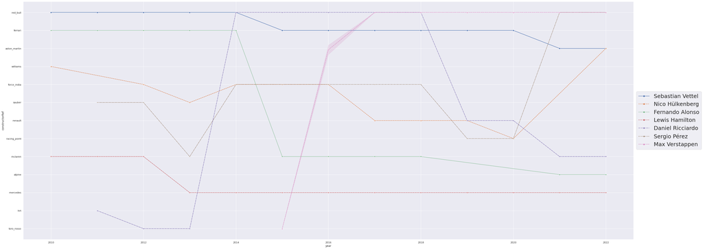

```python
# Now we are going to create a line plot that shows how these drivers moved over the years
# To limit how crezy the graph is, I am limiting my regression discontinuity to seven of the drivers. The drivers had more data and at least one team switch

import seaborn as sns
import matplotlib.pyplot as plt
plt.figure(figsize=(50,20))
sns.lineplot(data=results_seven, x="year", y="constructorRef", hue="Driver", markers = True, style = "Driver")
plt.legend(loc='center left', bbox_to_anchor=(1, 0.5), prop={'size': 25})
```

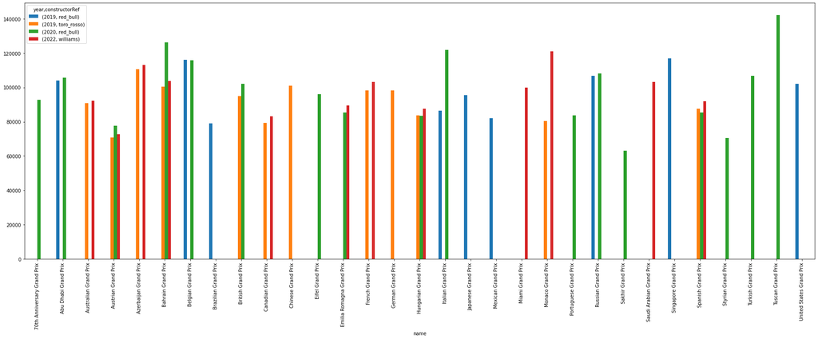

```python
alex_pivot = alexander_albon.pivot_table(
    index="name", columns=["year", "constructorRef"],
    values="milliseconds", aggfunc=np.mean)
alex_pivot.plot.bar(figsize = (30,10))
```

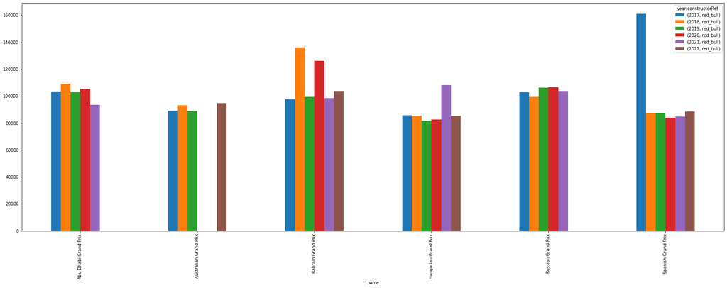

```python
max_verstappen = results_recent.loc[(results_recent['Driver'] == 'Max Verstappen')& (results_recent['year'] >=2017) & ((results_recent['name'] =="Hungarian Grand Prix") | (results_recent['name'] =="Abu Dhabi Grand Prix")| (results_recent['name'] =="Australian Grand Prix") | (results_recent['name'] =="Bahrain Grand Prix") | (results_recent['name'] =="Russian Grand Prix") | (results_recent['name'] =="Spanish Grand Prix"))]
max_pivot = max_verstappen.pivot_table(
    index="name", columns=["year", "constructorRef"],
    values="milliseconds", aggfunc=np.mean)
max_pivot.plot.bar(figsize = (30,10))
```

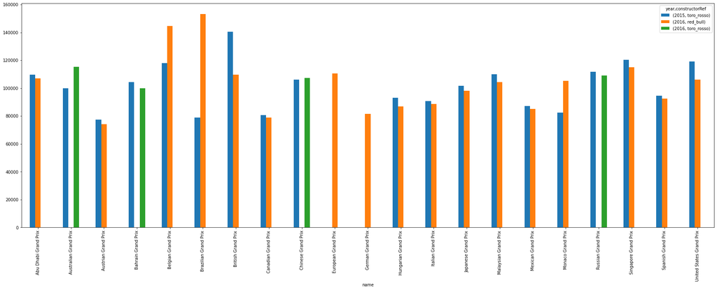

```python
max_verstappen = results_recent.loc[(results_recent['Driver'] == 'Max Verstappen') & ((results_recent['year'] ==2015) |(results_recent['year'] ==2016)) ]
max_pivot = max_verstappen.pivot_table(
    index="name", columns=["year", "constructorRef"],
    values="milliseconds", aggfunc=np.mean)
max_pivot.plot.bar(figsize = (30,10))
```

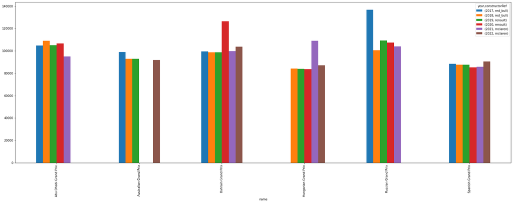

```python
daniel_ricciardo = results_recent.loc[(results_recent['Driver'] == 'Daniel Ricciardo')& (results_recent['year'] >=2017) & ((results_recent['name'] =="Hungarian Grand Prix") | (results_recent['name'] =="Abu Dhabi Grand Prix")| (results_recent['name'] =="Australian Grand Prix") | (results_recent['name'] =="Bahrain Grand Prix") | (results_recent['name'] =="Russian Grand Prix") | (results_recent['name'] =="Spanish Grand Prix"))]
daniel_pivot = daniel_ricciardo.pivot_table(
    index="name", columns=["year", "constructorRef"],
    values="milliseconds", aggfunc=np.mean)
daniel_pivot.plot.bar(figsize = (30,10))
```

```python
# the pivot table to end all pivot tables
table = pd.pivot_table(results_recent, values=['fastestLapTime'], index=['Driver','year', 'name'], aggfunc=np.max)
table
```

| Driver | year | name | fastestLapTime |
| --- | --- | --- | --- |
| Alexander Albon | 2019 | Abu Dhabi Grand Prix | 1:42.219 |
|  |  | Australian Grand Prix | 1:28.188 |
|  |  | Austrian Grand Prix | 1:08.946 |
|  |  | Azerbaijan Grand Prix | 1:45.754 |
|  |  | Bahrain Grand Prix | 1:36.752 |
| ... | ... | ... | ... |
| Yuki Tsunoda | 2022 | Hungarian Grand Prix | 1:23.538 |
|  |  | Miami Grand Prix | 1:33.035 |
|  |  | Monaco Grand Prix | 1:15.334 |
|  |  | Saudi Arabian Grand Prix | \N |
|  |  | Spanish Grand Prix | 1:26.828 |

6130 rows × 1 columns

# **Final Steps**

```python
# Converting my CoLab to html so that I can upload this file to Github
%%shell
jupyter nbconvert --to html /content/drive/MyDrive/finaltutorial.ipynb
```

[output not shown]

[output cut: 107 more lines]

[output not shown]

[output not shown]